# credit_card_eda

```python
import pandas as pd
import matplotlib.pyplot as plt
import seaborn as sns
```

## 1. EDA

**"df" dataset**

```python
# Load dataset
file_path = "data/credit_record.csv"

df =pd.read_csv(file_path)

print("Dataset Shape:", df.shape)
df.info()
```

```
Dataset Shape: (1048575, 3)
<class 'pandas.core.frame.DataFrame'>
RangeIndex: 1048575 entries, 0 to 1048574
Data columns (total 3 columns):
 #   Column          Non-Null Count    Dtype
---  ------          --------------    -----
 0   ID              1048575 non-null  int64
 1   MONTHS_BALANCE  1048575 non-null  int64
 2   STATUS          1048575 non-null  object
dtypes: int64(2), object(1)
memory usage: 24.0+ MB
```

### FEATURES EXPLANATION

**ID**: Client number

**MONTHS_BALANCE**: The month of the extracted data is the starting point, backwards. 0 is the current month, -1 is the previous month, and so on.

**STATUS**: Status of the credit

- 0: 1-29 days past due
- 1: 30-59 days past due
- 2: 60-89 days overdue
- 3: 90-119 days overdue
- 4: 120-149 days overdue
- 5: Overdue or bad debts, write-offs for more than 150 days
- C: Paid off that month
- X: No loan for the month

```python
# Summary of numerical columns
df.describe()

# Check for missing values
print("Missing Values:\n", df.isnull().sum())

# Check for duplicates
print("Duplicate Rows:", df.duplicated().sum())
```

```
Missing Values:
 ID                0
MONTHS_BALANCE    0
STATUS            0
dtype: int64
Duplicate Rows: 0
```

```python
df.groupby('STATUS').count()
```

| STATUS | ID | MONTHS_BALANCE |
| --- | --- | --- |
| 0 | 383120 | 383120 |
| 1 | 11090 | 11090 |
| 2 | 868 | 868 |
| 3 | 320 | 320 |
| 4 | 223 | 223 |
| 5 | 1693 | 1693 |
| C | 442031 | 442031 |
| X | 209230 | 209230 |

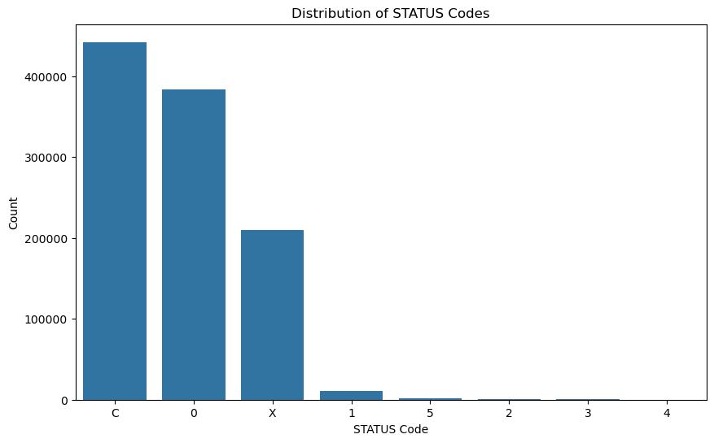

```python
# Plot STATUS distribution
plt.figure(figsize=(10, 6))
status_counts = df['STATUS'].value_counts()
sns.barplot(x=status_counts.index, y=status_counts.values)
plt.title('Distribution of STATUS Codes')
plt.xlabel('STATUS Code')
plt.ylabel('Count')
plt.show()
```

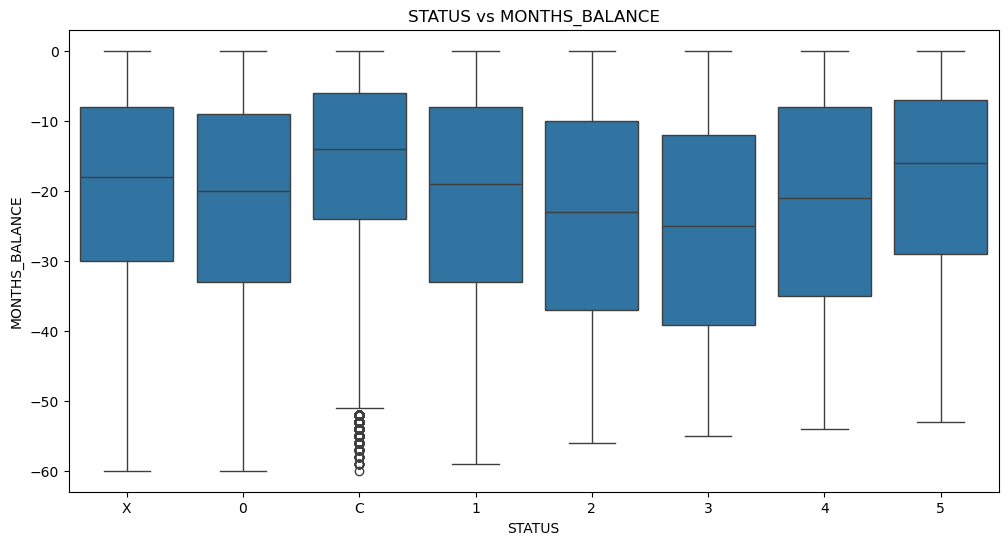

```python
plt.figure(figsize=(12, 6))
sns.boxplot(x='STATUS', y='MONTHS_BALANCE', data=df)
plt.title('STATUS vs MONTHS_BALANCE')
plt.show()
```

## Key Findings

### Data Composition:

- The dataset contains credit records with monthly status updates.
- Each record shows a client's credit status at a specific month (MONTHS_BALANCE).

### Status Distribution:

- Most common statuses are 'C' (Closed/Paid) and '0' (1-29 days late).
- Severe delinquency statuses ('3', '4', '5') are less common.

### Client Patterns:

- Some clients show consistent good behavior (all 'C' or 'X').
- Others show delinquency patterns that may start small and escalate.
- Some clients recover from delinquency.

### Potential Issues:

- Some IDs have very few records (may need filtering for analysis).
- Data is extremely unbalanced and will require preprocessing.

### Data Preprocessing

```python
# Convert STATUS to binary: 0 = low risk, 1 = high risk
df['STATUS'].replace({'C': 0, 'X': 0}, inplace=True)
df['STATUS'] = df['STATUS'].astype('int')
df['STATUS'] = df['STATUS'].apply(lambda x: 1 if x >= 2 else 0)

# Get the highest STATUS value for each ID
worst_status_per_id = df.groupby('ID')['STATUS'].max().reset_index()
```

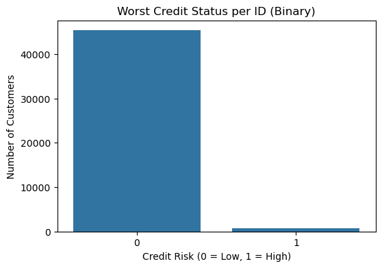

|  | ID | STATUS |
| --- | --- | --- |
| 0 | 5001711 | 0 |
| 1 | 5001712 | 0 |
| 2 | 5001713 | 0 |
| 3 | 5001714 | 0 |
| 4 | 5001715 | 0 |

```python
# Plot the distribution of high vs. low risk IDs
plt.figure(figsize=(6, 4))
sns.countplot(data=worst_status_per_id, x='STATUS')
plt.title("Worst Credit Status per ID (Binary)")
plt.xlabel("Credit Risk (0 = Low, 1 = High)")
plt.ylabel("Number of Customers")
plt.show()

worst_status_per_id.head()
```

```python
# Display Value Counts
worst_status_per_id.groupby('STATUS').count()
```

| STATUS | ID |
| --- | --- |
| 0 | 45318 |
| 1 | 667 |

### With the credit record preprocessed this way we can join it with the application record dataset

```python
# save to csv
worst_status_per_id.to_csv('data/credit_record_processed.csv', index = False)
```

```python
# reload the dataset from saved file
df0 = pd.read_csv('data/credit_record_processed.csv')
```

```python
# load the application dataset
df1 = pd.read_csv('data/application_record.csv')
```

```python
# merge dataframes together by ID
df = df0.merge(df1, on = 'ID', how = 'inner')
df.head()
```

|  | ID | STATUS | CODE_GENDER | FLAG_OWN_CAR | FLAG_OWN_REALTY | CNT_CHILDREN | AMT_INCOME_TOTAL | NAME_INCOME_TYPE | NAME_EDUCATION_TYPE | NAME_FAMILY_STATUS | NAME_HOUSING_TYPE | DAYS_BIRTH | DAYS_EMPLOYED | FLAG_MOBIL | FLAG_WORK_PHONE | FLAG_PHONE | FLAG_EMAIL | OCCUPATION_TYPE | CNT_FAM_MEMBERS |
| --- | --- | --- | --- | --- | --- | --- | --- | --- | --- | --- | --- | --- | --- | --- | --- | --- | --- | --- | --- |
| 0 | 5008804 | 0 | M | Y | Y | 0 | 427500.0 | Working | Higher education | Civil marriage | Rented apartment | -12005 | -4542 | 1 | 1 | 0 | 0 | NaN | 2.0 |
| 1 | 5008805 | 0 | M | Y | Y | 0 | 427500.0 | Working | Higher education | Civil marriage | Rented apartment | -12005 | -4542 | 1 | 1 | 0 | 0 | NaN | 2.0 |
| 2 | 5008806 | 0 | M | Y | Y | 0 | 112500.0 | Working | Secondary / secondary special | Married | House / apartment | -21474 | -1134 | 1 | 0 | 0 | 0 | Security staff | 2.0 |
| 3 | 5008808 | 0 | F | N | Y | 0 | 270000.0 | Commercial associate | Secondary / secondary special | Single / not married | House / apartment | -19110 | -3051 | 1 | 0 | 1 | 1 | Sales staff | 1.0 |
| 4 | 5008809 | 0 | F | N | Y | 0 | 270000.0 | Commercial associate | Secondary / secondary special | Single / not married | House / apartment | -19110 | -3051 | 1 | 0 | 1 | 1 | Sales staff | 1.0 |

```python
# save the combined dataset
df.to_csv('data/application_record_joined.csv', index = False)
```

```python
# reload the dataset
df  = pd.read_csv('data/application_record_joined.csv')
```

### Now we can carry out an EDA on the combined dataset

```python
df.info()
```

```
<class 'pandas.core.frame.DataFrame'>
RangeIndex: 36457 entries, 0 to 36456
Data columns (total 19 columns):
 #   Column               Non-Null Count  Dtype
---  ------               --------------  -----
 0   ID                   36457 non-null  int64
 1   STATUS               36457 non-null  int64
 2   CODE_GENDER          36457 non-null  object
 3   FLAG_OWN_CAR         36457 non-null  object
 4   FLAG_OWN_REALTY      36457 non-null  object
 5   CNT_CHILDREN         36457 non-null  int64
 6   AMT_INCOME_TOTAL     36457 non-null  float64
 7   NAME_INCOME_TYPE     36457 non-null  object
 8   NAME_EDUCATION_TYPE  36457 non-null  object
 9   NAME_FAMILY_STATUS   36457 non-null  object
 10  NAME_HOUSING_TYPE    36457 non-null  object
 11  DAYS_BIRTH           36457 non-null  int64
 12  DAYS_EMPLOYED        36457 non-null  int64
 13  FLAG_MOBIL           36457 non-null  int64
 14  FLAG_WORK_PHONE      36457 non-null  int64
 15  FLAG_PHONE           36457 non-null  int64
 16  FLAG_EMAIL           36457 non-null  int64
 17  OCCUPATION_TYPE      25134 non-null  object
 18  CNT_FAM_MEMBERS      36457 non-null  float64
dtypes: float64(2), int64(9), object(8)
memory usage: 5.3+ MB
```

```python
# Summary of numerical columns
df.describe()

# Check for missing values
print("Missing Values:\n", df.isnull().sum())

# Check for duplicates
print("Duplicate Rows:", df.duplicated().sum())
```

```
Missing Values:
 ID                         0
STATUS                     0
CODE_GENDER                0
FLAG_OWN_CAR               0
FLAG_OWN_REALTY            0
CNT_CHILDREN               0
AMT_INCOME_TOTAL           0
NAME_INCOME_TYPE           0
NAME_EDUCATION_TYPE        0
NAME_FAMILY_STATUS         0
NAME_HOUSING_TYPE          0
DAYS_BIRTH                 0
DAYS_EMPLOYED              0
FLAG_MOBIL                 0
FLAG_WORK_PHONE            0
FLAG_PHONE                 0
FLAG_EMAIL                 0
OCCUPATION_TYPE        11323
CNT_FAM_MEMBERS            0
dtype: int64
Duplicate Rows: 0
```

## 🧹 Insights

- ✅ No duplicate rows.
- ⚠️ `DAYS_BIRTH` and `DAYS_EMPLOYED` are in negative values — needs conversion to positive years.
- 🛠 Some categorical features (like car/realty flags) are encoded as "Y"/"N" and need conversion.
- ⚠️ `OCCUPATION_TYPE` has missing values — something to examine in the next step.

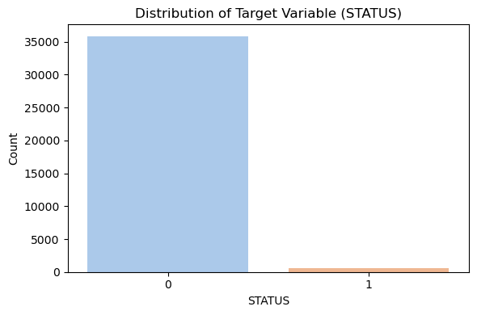

| STATUS | Count | Percentage |
| --- | --- | --- |
| 0 | 35841 | 98.31 |
| 1 | 616 | 1.69 |

```python
# Step 2: Target Variable Inspection
target_col = 'STATUS'

# Value counts and percentages
target_counts = df[target_col].value_counts()
target_percent = df[target_col].value_counts(normalize=True) * 100

# Plot class distribution
plt.figure(figsize=(6, 4))
sns.countplot(x=target_col, hue=target_col, data=df, palette="pastel", legend=False)
plt.title("Distribution of Target Variable (STATUS)")
plt.xlabel("STATUS")
plt.ylabel("Count")
plt.tight_layout()
plt.show()

# Combine insights
target_summary = pd.DataFrame({
    "Count": target_counts,
    "Percentage": target_percent.round(2)
})

target_summary
```

### 📊 Distribution Insights

- Like we noticed ealrier the dataset is higly imbalanced.
- Only 1.69% of records are labeled as high-risk.
- This imbalance will require attention later when building models (e.g., resampling, class weights, anomaly detection, etc.).

### Missing values

```python
# Count and percentage of missing values
missing_count = df.isnull().sum()
missing_percent = (df.isnull().sum() / len(df)) * 100

# Filter columns with missing values
missing_data = pd.DataFrame({
    'Missing Count': missing_count,
    'Missing Percentage': missing_percent
}).query('`Missing Count` > 0').sort_values(by='Missing Percentage', ascending=False)


missing_data
```

|  | Missing Count | Missing Percentage |
| --- | --- | --- |
| OCCUPATION_TYPE | 11323 | 31.058507 |

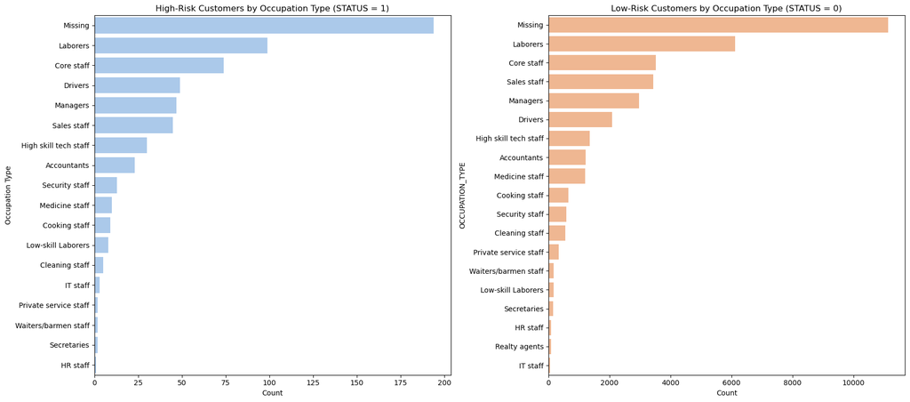

```python
# Prepare high-risk data
high_risk_df = df[df["STATUS"] == 1]
occupation_counts_high_risk = high_risk_df["OCCUPATION_TYPE"].value_counts(dropna=False).reset_index()
occupation_counts_high_risk.columns = ["OCCUPATION_TYPE", "Count"]
occupation_counts_high_risk["OCCUPATION_TYPE"] = occupation_counts_high_risk["OCCUPATION_TYPE"].fillna("Missing")
occupation_counts_high_risk = occupation_counts_high_risk.sort_values(by="Count", ascending=False)

# Prepare low-risk data
low_risk_df = df[df["STATUS"] == 0]
occupation_counts_low_risk = low_risk_df["OCCUPATION_TYPE"].value_counts(dropna=False).reset_index()
occupation_counts_low_risk.columns = ["OCCUPATION_TYPE", "Count"]
occupation_counts_low_risk["OCCUPATION_TYPE"] = occupation_counts_low_risk["OCCUPATION_TYPE"].fillna("Missing")
occupation_counts_low_risk = occupation_counts_low_risk.sort_values(by="Count", ascending=False)

# Create side-by-side bar plots
fig, axes = plt.subplots(1, 2, figsize=(18, 8), sharex=False)

# High-risk plot
sns.barplot(ax=axes[0], data=occupation_counts_high_risk, y="OCCUPATION_TYPE", x="Count")
axes[0].set_title("High-Risk Customers by Occupation Type (STATUS = 1)")
axes[0].set_xlabel("Count")
axes[0].set_ylabel("Occupation Type")

# Low-risk plot
sns.barplot(ax=axes[1], data=occupation_counts_low_risk, y="OCCUPATION_TYPE", x="Count")
axes[1].set_title("Low-Risk Customers by Occupation Type (STATUS = 0)")
axes[1].set_xlabel("Count")
axes[1].set_ylabel("")

pastel_colors = sns.color_palette("pastel", n_colors=len(occupation_counts_high_risk))

sns.barplot(ax=axes[0], data=occupation_counts_high_risk, y="OCCUPATION_TYPE", x="Count", color=pastel_colors[0])
sns.barplot(ax=axes[1], data=occupation_counts_low_risk, y="OCCUPATION_TYPE", x="Count", color=pastel_colors[1])


plt.tight_layout()
plt.show()
```

- OCCUPATION_TYPE is missing in nearly 1 in 3 records - even in the high risk group.

About 31% (194 out of 616) high-risk customers have missing occupation info.

Laborers, core staff, and drivers are the top 3 known occupations in the high-risk group.

This suggests that occupation type could be predictive for risk classification.

This feature may still hold valuable information but needs thoughtful handling:

✅ Leave missing as a separate category ("Unknown" or NaN) if using tree-based models.

🔁 Impute with the mode (most common value) if that makes sense for your data.

📉 Consider excluding the feature if it's not predictive or causes data leakage.

### Data Types & Conversion

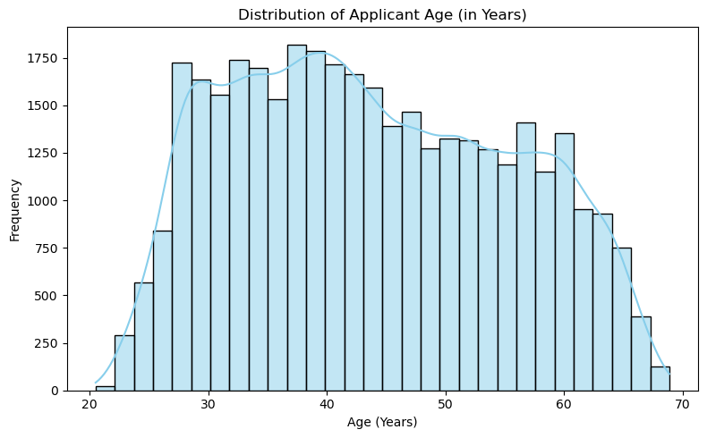

```
{'Categorical Columns': ['CODE_GENDER',
  'FLAG_OWN_CAR',
  'FLAG_OWN_REALTY',
  'NAME_INCOME_TYPE',
  'NAME_EDUCATION_TYPE',
  'NAME_FAMILY_STATUS',
  'NAME_HOUSING_TYPE',
  'OCCUPATION_TYPE'],
 'Numerical Columns': ['ID',
  'STATUS',
  'CNT_CHILDREN',
  'AMT_INCOME_TOTAL',
  'DAYS_BIRTH',
  'DAYS_EMPLOYED',
  'FLAG_MOBIL',
  'FLAG_WORK_PHONE',
  'FLAG_PHONE',
  'FLAG_EMAIL',
  'CNT_FAM_MEMBERS'],
 'Binary Flags': ['STATUS', 'FLAG_WORK_PHONE', 'FLAG_PHONE', 'FLAG_EMAIL'],
 'New Features Added': ['AGE_YEARS', 'YEARS_EMPLOYED']}
```

```python
# Step 4: Data Types & Conversion

# Identify current data types
data_types = df.dtypes

# Identify categorical columns
categorical_cols = df.select_dtypes(include=["object"]).columns.tolist()

# Identify numerical columns
numerical_cols = df.select_dtypes(include=["int64", "float64"]).columns.tolist()

# Identify binary flag columns (likely to be 0/1)
binary_flags = [col for col in numerical_cols if df[col].dropna().nunique() == 2]

# Check if any date-like conversion is needed
# DAYS_BIRTH and DAYS_EMPLOYED appear to be durations in days (negative values)
df["AGE_YEARS"] = (-df["DAYS_BIRTH"] / 365).round(1)
df["YEARS_EMPLOYED"] = df["DAYS_EMPLOYED"].apply(lambda x: x if x < 0 else None)
df["YEARS_EMPLOYED"] = (-df["YEARS_EMPLOYED"] / 365).round(1)

# Prepare a summary
data_conversion_summary = {
    "Categorical Columns": categorical_cols,
    "Numerical Columns": numerical_cols,
    "Binary Flags": binary_flags,
    "New Features Added": ["AGE_YEARS", "YEARS_EMPLOYED"]
}

import seaborn as sns
import matplotlib.pyplot as plt

# Quick plot to show age distribution
plt.figure(figsize=(8, 5))
sns.histplot(df["AGE_YEARS"], bins=30, kde=True, color="skyblue")
plt.title("Distribution of Applicant Age (in Years)")
plt.xlabel("Age (Years)")
plt.ylabel("Frequency")
plt.tight_layout()
plt.show()

data_conversion_summary
```

### 🗂 Categorical Columns (8)

These will need encoding for modeling:

- `CODE_GENDER`
- `FLAG_OWN_CAR`
- `FLAG_OWN_REALTY`
- `NAME_INCOME_TYPE`
- `NAME_EDUCATION_TYPE`
- `NAME_FAMILY_STATUS`
- `NAME_HOUSING_TYPE`
- `OCCUPATION_TYPE`

### 🔢 Numerical Columns (11)

Includes ID, income, age, employment, and family size:

- `ID`
- `STATUS`
- `CNT_CHILDREN`
- `AMT_INCOME_TOTAL`
- `DAYS_BIRTH`
- `DAYS_EMPLOYED`
- `CNT_FAM_MEMBERS`

Plus binary flags:

- `FLAG_MOBIL`
- `FLAG_WORK_PHONE`
- `FLAG_PHONE`
- `FLAG_EMAIL`

### ⚑ Binary Flags (4)

These are already in 0/1 format and ready to use:

- `STATUS` (target)
- `FLAG_WORK_PHONE`
- `FLAG_PHONE`
- `FLAG_EMAIL`

### 🆕 New Features Created

To improve interpretability:

- `AGE_YEARS` (converted from `DAYS_BIRTH`)
- `YEARS_EMPLOYED` (cleaned from `DAYS_EMPLOYED`, excludes outliers like 365243)

### Univariate Analysis

#### Numerical Features

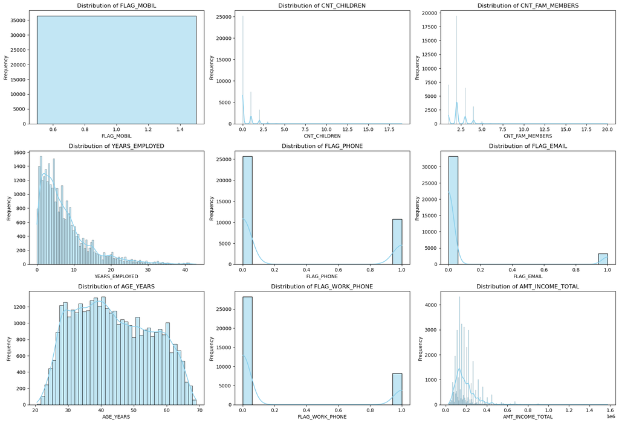

```python
# Fixing duplicated AGE_YEARS and YEARS_EMPLOYED in the plots

# Recreate derived columns
df["AGE_YEARS"] = (-df["DAYS_BIRTH"] / 365).round(1)
df["YEARS_EMPLOYED"] = df["DAYS_EMPLOYED"].apply(lambda x: x if x < 0 else None)
df["YEARS_EMPLOYED"] = (-df["YEARS_EMPLOYED"] / 365).round(1)

# Step 5: Univariate Analysis - Numerical features
exclude_cols = ["ID", "STATUS", "DAYS_BIRTH", "DAYS_EMPLOYED"]
base_num_features = [col for col in df.select_dtypes(include=["int64", "float64"]).columns if col not in exclude_cols]

# Add derived columns without duplication
num_features = list(set(base_num_features + ["AGE_YEARS", "YEARS_EMPLOYED"]))

# Plot distributions
n = len(num_features)
rows = (n // 3) + 1

fig, axes = plt.subplots(rows, 3, figsize=(18, rows * 4))
axes = axes.flatten()

for i, col in enumerate(num_features):
    sns.histplot(df[col].dropna(), ax=axes[i], kde=True, color="skyblue")
    axes[i].set_title(f"Distribution of {col}")
    axes[i].set_xlabel(col)
    axes[i].set_ylabel("Frequency")

for j in range(i + 1, len(axes)):
    fig.delaxes(axes[j])  # Remove unused axes

plt.tight_layout()
plt.show()
```

📊 Insights from Distributions:

#### Categorical Features

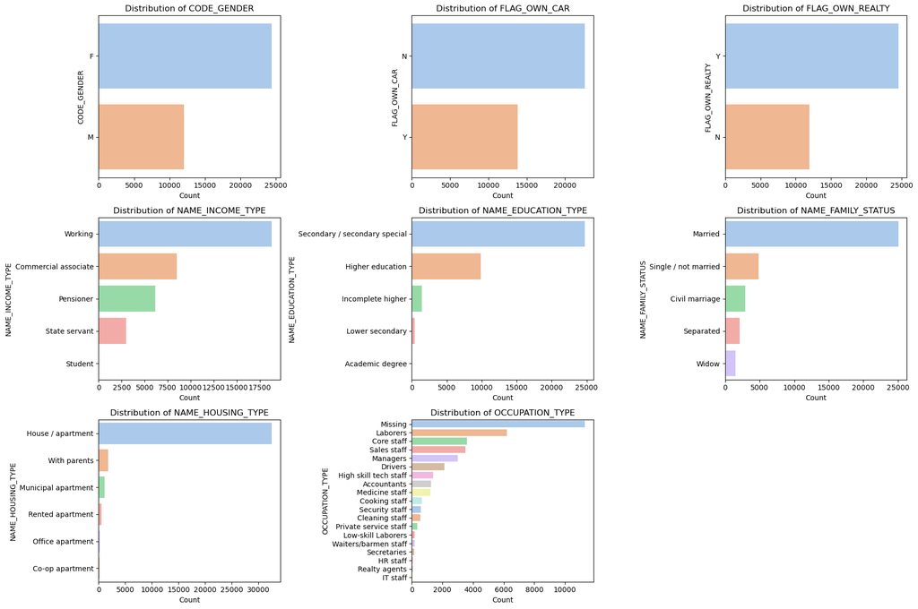

```python
# Step 5: Univariate Analysis - Categorical features (Clean version with future warning fix)

# Identify categorical columns
categorical_cols = df.select_dtypes(include=["object"]).columns.tolist()

# Create bar plots for each categorical column
n = len(categorical_cols)
rows = (n // 3) + 1

fig, axes = plt.subplots(rows, 3, figsize=(18, rows * 4))
axes = axes.flatten()

for i, col in enumerate(categorical_cols):
    value_counts = df[col].fillna("Missing").value_counts().reset_index()
    value_counts.columns = [col, "Count"]
    # Assign the 'y' variable to hue and disable the legend to remove the warning
    sns.barplot(
        data=value_counts,
        x="Count",
        y=col,
        ax=axes[i],
        hue=col,
        palette="pastel",
        legend=False
    )
    axes[i].set_title(f"Distribution of {col}")
    axes[i].set_xlabel("Count")
    axes[i].set_ylabel(col)

for j in range(i + 1, len(axes)):
    fig.delaxes(axes[j])  # Remove unused axes

plt.tight_layout()
plt.show()
```

Key Takeaways:

- CODE_GENDER: Strong skew toward females.
- FLAG_OWN_CAR & FLAG_OWN_REALTY: Many customers own real estate, fewer own cars.
- NAME_INCOME_TYPE & NAME_EDUCATION_TYPE: Most applicants are “Working” with secondary or higher education.
- NAME_FAMILY_STATUS & NAME_HOUSING_TYPE: "Married" and "House / apartment" are dominant.

## Bivariate Analysis

#### Cathegorical Features

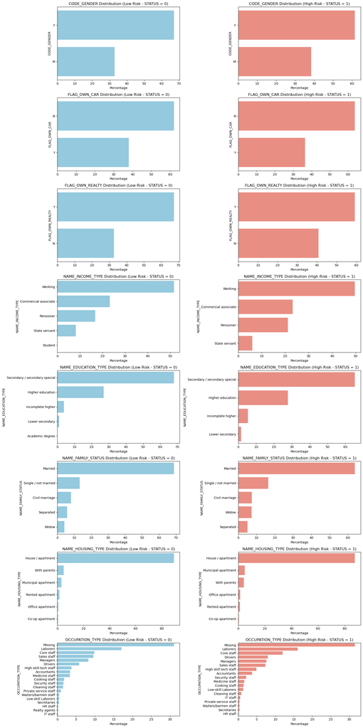

```python
# Step 6: Alternative Bivariate Analysis - Compare high vs low risk separately using % scale

# Reload categorical columns
categorical_cols = df.select_dtypes(include=["object"]).columns.tolist()

# Prepare separate proportions for STATUS = 0 and STATUS = 1
status_0 = df[df["STATUS"] == 0]
status_1 = df[df["STATUS"] == 1]

# Prepare figure
n = len(categorical_cols)
rows = n
fig, axes = plt.subplots(rows, 2, figsize=(16, rows * 4))
fig.subplots_adjust(hspace=0.4)

for i, col in enumerate(categorical_cols):
    # Get normalized value counts (percentages)
    low_risk_pct = status_0[col].fillna("Missing").value_counts(normalize=True) * 100
    high_risk_pct = status_1[col].fillna("Missing").value_counts(normalize=True) * 100

    # Convert to DataFrame
    low_risk_df = low_risk_pct.reset_index()
    low_risk_df.columns = [col, "Percentage"]
    high_risk_df = high_risk_pct.reset_index()
    high_risk_df.columns = [col, "Percentage"]

    # Sort for consistency
    low_risk_df = low_risk_df.sort_values(by="Percentage", ascending=False)
    high_risk_df = high_risk_df.sort_values(by="Percentage", ascending=False)

    # Plot low risk
    sns.barplot(data=low_risk_df, y=col, x="Percentage", ax=axes[i, 0], color="skyblue")  # Removed palette
    axes[i, 0].set_title(f"{col} Distribution (Low Risk - STATUS = 0)")

    # Plot high risk
    sns.barplot(data=high_risk_df, y=col, x="Percentage", ax=axes[i, 1], color="salmon")  # Removed palette
    axes[i, 1].set_title(f"{col} Distribution (High Risk - STATUS = 1)")




plt.tight_layout()
plt.show()
```

#### Numericla Features - boxplots

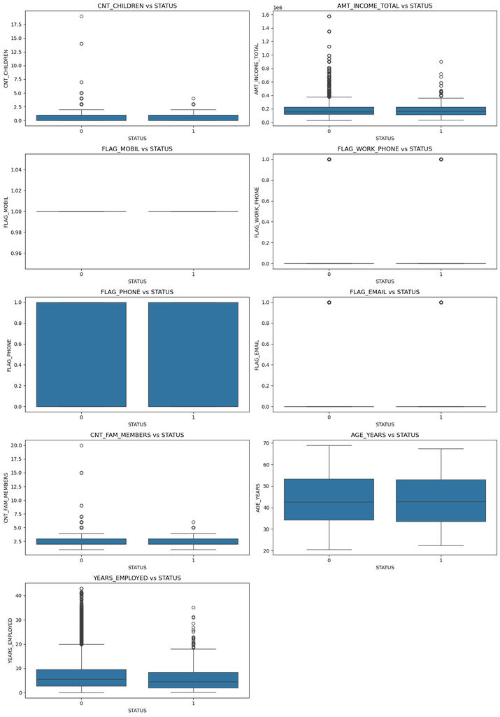

```python
# Step 6: Bivariate Analysis - Numerical features vs STATUS (boxplots)

# Define numerical columns to analyze (exclude ID and raw days)
exclude_cols = ["ID", "DAYS_BIRTH", "DAYS_EMPLOYED", "STATUS"]
num_features = [col for col in df.select_dtypes(include=["int64", "float64"]).columns if col not in exclude_cols]
num_features += ["AGE_YEARS", "YEARS_EMPLOYED"]

# Drop duplicates if AGE_YEARS and YEARS_EMPLOYED were already included
num_features = list(dict.fromkeys(num_features))

# Create plots
n = len(num_features)
rows = (n // 2) + 1

fig, axes = plt.subplots(rows, 2, figsize=(14, rows * 4))
axes = axes.flatten()

for i, col in enumerate(num_features):
    sns.boxplot(data=df, x="STATUS", y=col, ax=axes[i])  # Removed palette
    axes[i].set_title(f"{col} vs STATUS")
    axes[i].set_xlabel("STATUS")
    axes[i].set_ylabel(col)

for j in range(i + 1, len(axes)):
    fig.delaxes(axes[j])  # Remove unused axes

plt.tight_layout()
plt.show()
```

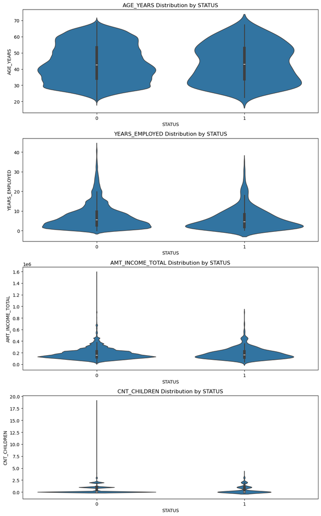

```python
# Violin plots for key numerical features vs STATUS

# Select a few key features that showed interesting patterns
key_features = ["AGE_YEARS", "YEARS_EMPLOYED", "AMT_INCOME_TOTAL", "CNT_CHILDREN"]

# Plot violin plots
n = len(key_features)
fig, axes = plt.subplots(n, 1, figsize=(10, n * 4))

for i, col in enumerate(key_features):
    sns.violinplot(data=df, x="STATUS", y=col, ax=axes[i], inner="box")  # Removed palette
    axes[i].set_title(f"{col} Distribution by STATUS")
    axes[i].set_xlabel("STATUS")
    axes[i].set_ylabel(col)

plt.tight_layout()
plt.show()
```

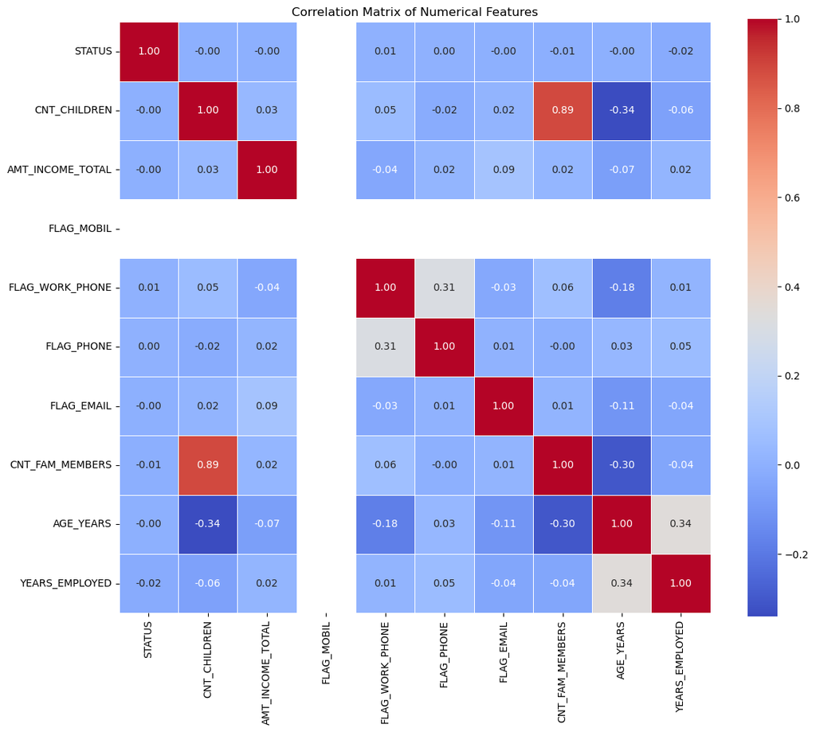

```python
# Recreate derived columns
df["AGE_YEARS"] = (-df["DAYS_BIRTH"] / 365).round(1)
df["YEARS_EMPLOYED"] = df["DAYS_EMPLOYED"].apply(lambda x: x if x < 0 else None)
df["YEARS_EMPLOYED"] = (-df["YEARS_EMPLOYED"] / 365).round(1)

# Step 7.1: Correlation Heatmap for Numerical Features
exclude_cols = ["ID", "DAYS_BIRTH", "DAYS_EMPLOYED"]
num_corr_features = [col for col in df.select_dtypes(include=["int64", "float64"]).columns if col not in exclude_cols]
num_corr_features += ["AGE_YEARS", "YEARS_EMPLOYED"]
num_corr_features = list(dict.fromkeys(num_corr_features))  # Remove duplicates

# Compute correlation matrix
corr_matrix = df[num_corr_features].corr()

# Plot heatmap
plt.figure(figsize=(12, 10))
sns.heatmap(corr_matrix, annot=True, fmt=".2f", cmap="coolwarm", square=True, linewidths=0.5)
plt.title("Correlation Matrix of Numerical Features")
plt.tight_layout()
plt.show()
```

Key Observations:

- ✅ AGE_YEARS and YEARS_EMPLOYED show a moderate positive correlation — older individuals tend to have longer employment history.
- 🧮 CNT_CHILDREN and CNT_FAM_MEMBERS are strongly correlated (as expected).
- ⚠️ AMT_INCOME_TOTAL and other features are mostly weakly correlated, which is good for modeling — less risk of multicollinearity.
- 🔄 STATUS (our target) has weak correlations with all features — common in real-world classification tasks.

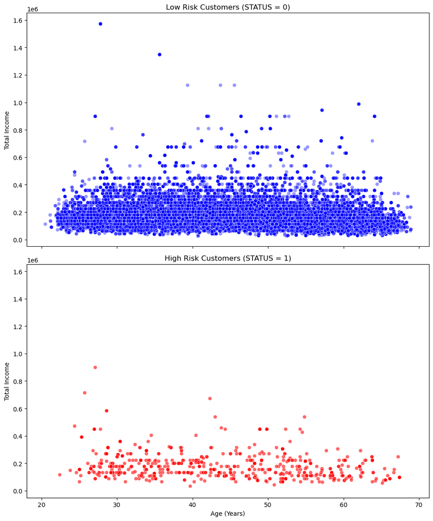

```python
# Split data by STATUS
low_risk = df[df["STATUS"] == 0]
high_risk = df[df["STATUS"] == 1]

# Create a 2-row, 1-column plot matrix
fig, axes = plt.subplots(2, 1, figsize=(10, 12), sharex=True, sharey=True)

# Plot for low risk
sns.scatterplot(ax=axes[0], data=low_risk, x="AGE_YEARS", y="AMT_INCOME_TOTAL", color="blue", alpha=0.4)
axes[0].set_title("Low Risk Customers (STATUS = 0)")
axes[0].set_xlabel("Age (Years)")
axes[0].set_ylabel("Total Income")

# Plot for high risk
sns.scatterplot(ax=axes[1], data=high_risk, x="AGE_YEARS", y="AMT_INCOME_TOTAL", color="red", alpha=0.6)
axes[1].set_title("High Risk Customers (STATUS = 1)")
axes[1].set_xlabel("Age (Years)")
axes[1].set_ylabel("Total Income")

plt.tight_layout()
plt.show()
```

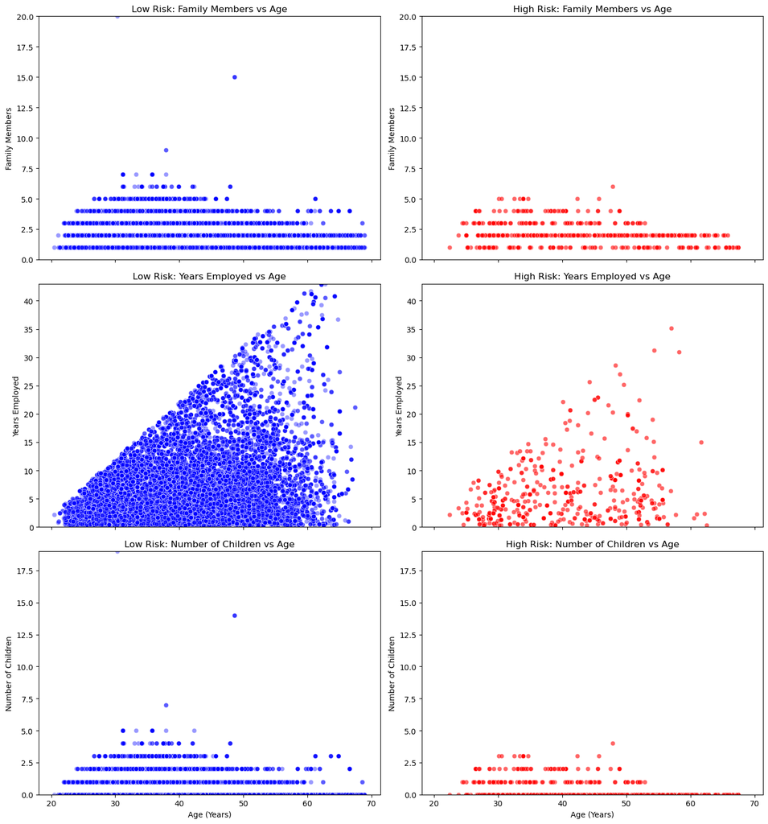

```python
# Create plot matrix: 3 rows x 2 columns (low risk left, high risk right)
fig, axes = plt.subplots(nrows=3, ncols=2, figsize=(14, 15), sharex=True)

# Define features and titles
features = ["CNT_FAM_MEMBERS", "YEARS_EMPLOYED", "CNT_CHILDREN"]
titles = ["Family Members", "Years Employed", "Number of Children"]

# Compute consistent y-limits for each feature
y_limits = {
    feature: (
        min(df[feature].min(), 0),
        df[feature].max()
    ) for feature in features
}

# Loop through each feature and plot for low and high risk with shared y-limits
for i, (feature, title) in enumerate(zip(features, titles)):
    # Low risk (left)
    sns.scatterplot(ax=axes[i, 0], data=low_risk, x="AGE_YEARS", y=feature, color="blue", alpha=0.4)
    axes[i, 0].set_title(f"Low Risk: {title} vs Age")
    axes[i, 0].set_ylabel(title)
    axes[i, 0].set_ylim(y_limits[feature])
    axes[i, 0].set_xlabel("Age (Years)")

    # High risk (right)
    sns.scatterplot(ax=axes[i, 1], data=high_risk, x="AGE_YEARS", y=feature, color="red", alpha=0.6)
    axes[i, 1].set_title(f"High Risk: {title} vs Age")
    axes[i, 1].set_ylabel(title)
    axes[i, 1].set_ylim(y_limits[feature])
    axes[i, 1].set_xlabel("Age (Years)")

plt.tight_layout()
plt.show()
```

## 🧾 EDA Summary for Customer Risk Prediction

#### **Step 1: Data Overview**

- **Records:** 36,457
- **Columns:** 19
- ✅ No duplicate rows
- 🎯 **Target Variable:** `STATUS` (binary)

#### **Step 2: Target Analysis**

- ⚠️ **Imbalanced classes**
  - `STATUS = 0` (Low Risk): **98.3%**
  - `STATUS = 1` (High Risk): **1.7%**

#### **Step 3: Missing Values**

- 🕳️ Only `OCCUPATION_TYPE` has missing data (~31%)

#### **Step 4: Data Types & Conversion**

- 📦 Identified:
  - Categorical, numerical, and binary columns
- 🔧 Created:
  - `AGE_YEARS` from `DAYS_BIRTH`
  - Cleaned `YEARS_EMPLOYED` (removed anomalies)

#### **Step 5: Univariate Analysis**

- 📊 Visualized distributions for:
  - Numerical: histograms + KDE
  - Categorical: bar plots
- 🧠 Key insights:
  - Skewed income distribution
  - Age concentrated around working years
  - Binary features imbalanced (e.g., `FLAG_EMAIL`)

```python
df.to_csv('bank-loan-data/application_record_ml_ready.csv', index = False)
```

```python
!jupyter nbconvert credit_card_eda.ipynb --to html --no-input --no-prompt --output credit_card_eda.html
```

```
[NbConvertApp] Converting notebook credit_card_eda.ipynb to html
[NbConvertApp] WARNING | Alternative text is missing on 14 image(s).
[NbConvertApp] Writing 2593311 bytes to credit_card_eda.html
```